# Thesis

Dadmehr Didgart

2023-09-12

## Note on Package Loading with pacman::p_load()

The `pacman::p_load()` function is responsible for loading multiple R packages in one go. If a specified package is not installed, the function will install it before loading. This line is essentially setting up the environment by ensuring that all the required packages for the project are loaded and ready for use. The list of packages covers a wide range of functionalities including data manipulation, plotting, statistical analysis, and more.

```r
# Load all necessary packages for analysis using the pacman package manager
pacman::p_load(ggplot2, ipumsr, dplyr, MASS, plotly, ggeasy, stargazer, usethis, tictoc, pryr, smoothie, Gini, dineq, sjlabelled, expss, readxl, broom, GGally, coefplot, dotwhisker, labelled, broom.helpers, ivreg, arrow, fields, labelled, olsrr, dgumbel, gridExtra, ggstance, gumbel, tidyverse, data.table, lubridate, purrr, stringr, ggplot2, tidyr, dplyr, readr, plotly, broom, gridExtra, ggpubr, forcats, knitr, RColorBrewer, rmarkdown, shiny, shinydashboard, devtools, testthat, stringi, scales, magrittr, ggthemes, broom.helpers, patchwork, cowplot, reshape2, ggsci, tibble, dtplyr, ggrepel, pander, ggpmisc, foreach, pheatmap, kableExtra, leaflet, ggmap, rvest, jsonlite, XML, ggforce, glue, hrbrthemes, flexdashboard, lattice, nycflights13, igraph, DoseFinding, effectsize, epiR, graphlayouts, Guerry, lava, maxLik, plotrix, projpred, psychotools, RNetCDF, ROCR, rpact, sn, coronavirus, rmarkdown, tidyverse, ggthemes, plotly, xfun, magick, jsonlite, magrittr, tidycensus, rvest, httr, tidygraph, igraph, ggraph, gapminder, leaflet, gssr, gtrendsR, ggplot2, PWFSLSmoke, AirSensor, AirMonitorPlots, MazamaSpatialUtils, lubridate, VennDiagram, janitor, skimr, DataExplorer, stringr, nycflights13, pandoc)
```

## Note on Data Preprocessing and Analysis Workflow

This script primarily focuses on loading and manipulating a dataset related to U.S. demographics, presumably obtained from IPUMS. Below is a breakdown of what the script does:

1. **Setting Working Directory**: The working directory is set to a specific folder on the user’s computer.
2. **Package Requirement**: Checks for the `ipumsr` package and stops execution if the package is not found.
3. **Data Reading**: Reads metadata (`usa_00036.xml`) and actual microdata (`main_data`) using the IPUMS DDI (Data Documentation Initiative) schema.
4. **Data Subsetting**: Creates multiple subsets of the main data based on certain conditions, such as marital status, income, year, etc.
5. **Variable Creation**: Adds new variables (`mom`, `dad`, `parent`) to `main_data`.
6. **Quantile Analysis**: Creates income, age, race, and education grids by computing quantiles for multiple subsets (`m_main_data`, `jm_main_data`, `co_main_data`).
7. **Data Finalization**: Adjusts the generated grids by removing the first element.
8. **Year Selection**: Optionally filters the data by year (`n_year`).

Note: The use of `<<-` suggests that the variables are being created in the global environment, which may impact other parts of the code or R session.

```r
setwd("/Users/dadmehr/R")
if (!require("ipumsr")) stop("Reading IPUMS data into R requires the ipumsr package. It can be installed using the following command: install.packages('ipumsr')")
ddi <- read_ipums_ddi("usa_00036.xml")
main_data <- read_ipums_micro(ddi)
```

```
## Use of data from IPUMS USA is subject to conditions including that users should
## cite the data appropriately. Use command `ipums_conditions()` for more details.
```

```r
m_main_data <- subset(main_data, INCTOT !=9999999 & MARST %in% c(1,2) & MARRINYR != 2 & YEAR==2021)
jm_main_data <- subset(main_data, INCTOT !=9999999 & MARRINYR == 2 & YEAR==2021)
co_main_data <- subset(main_data, INCTOT !=9999999 & COUPLETYPE == 3 & MARST == 6 & YEAR==2021)
co_2021 <- subset(main_data, INCTOT !=9999999 & YEAR==2021 & COUPLETYPE == 3 & MARST == 6)

main_data <- main_data %>% mutate(mom = case_when(MOMLOC > 0 ~ 1, !MOMLOC > 0 ~ 0))
main_data <- main_data %>% mutate(dad = case_when(POPLOC > 0 ~ 1, !POPLOC > 0 ~ 0))
main_data <- main_data %>% mutate(parent = case_when(abs(dad+mom) > 0 ~ 1, !abs(dad+mom) > 0 ~ 0))



cut_by <- 0.1

m_income_grid <<- sort(unique(as.integer(c(quantile(m_main_data$INCTOT, probs = seq(0, 1, by = cut_by))))))
m_age_grid <<- sort(unique(as.integer(c(quantile(m_main_data$AGE, probs = seq(0, 1, by = cut_by))))))
m_race_grid <<- sort(unique(as.integer(c(quantile(m_main_data$RACE, probs = seq(0, 1, by = 0.2))))))
m_edu_grid <<- sort(unique(as.integer(c(quantile(m_main_data$EDUCD, probs = seq(0, 1, by = 0.2))))))

m_income_grid <- m_income_grid[-1]
m_age_grid <- m_age_grid[-1]
m_race_grid <- m_race_grid[-1]
m_edu_grid <- m_edu_grid[-1]

jm_income_grid <<- sort(unique(as.integer(c(quantile(jm_main_data$INCTOT, probs = seq(0, 1, by = cut_by))))))
jm_age_grid <<- sort(unique(as.integer(c(quantile(jm_main_data$AGE, probs = seq(0, 1, by = cut_by))))))
jm_race_grid <<- sort(unique(as.integer(c(quantile(jm_main_data$RACE, probs = seq(0, 1, by = 0.2))))))
jm_edu_grid <<- sort(unique(as.integer(c(quantile(jm_main_data$EDUCD, probs = seq(0, 1, by = 0.2))))))

jm_income_grid <- jm_income_grid[-1]
jm_age_grid <- jm_age_grid[-1]
jm_race_grid <- jm_race_grid[-1]
jm_edu_grid <- jm_edu_grid[-1]

co_income_grid <<- sort(unique(as.integer(c(quantile(co_main_data$INCTOT, probs = seq(0, 1, by = cut_by))))))
co_age_grid <<- sort(unique(as.integer(c(quantile(co_main_data$AGE, probs = seq(0, 1, by = cut_by))))))
co_race_grid <<- sort(unique(as.integer(c(quantile(co_main_data$RACE, probs = seq(0, 1, by = 0.2))))))
co_edu_grid <<- sort(unique(as.integer(c(quantile(co_main_data$EDUCD, probs = seq(0, 1, by = 0.2))))))

co_income_grid <- co_income_grid[-1]
co_age_grid <- co_age_grid[-1]
co_race_grid <- co_race_grid[-1]
co_edu_grid <- co_edu_grid[-1]


m_race_grid <<- jm_race_grid <<- co_race_grid <<- race_gridrace_grid <<- c(1,2,6,9)
m_edu_grid <<- jm_edu_grid <<- co_edu_grid <<- edu_grid <<- c(63,81,101,116)

n_age <<- length(jm_age_grid)
n_income <<- length(jm_income_grid)
n_edu <<- length(jm_edu_grid)
n_race <<- length(jm_race_grid)

n_year=2021
if (n_year!=-1){data <- subset(main_data,main_data$YEAR == n_year)}
```

## Note on Functions and Label Mappings

This script block contains two primary components:

1. **Gumbel Functions**: Three functions (`F_gumbel`, `gumbel`, and `G_gumbel`) are defined for Gumbel distribution calculations.
   - `F_gumbel(n)`: Calculates the Gumbel distribution’s cumulative distribution function (CDF) using input `n`.
   - `gumbel(n)`: Essentially identical to `F_gumbel`, calculates the Gumbel CDF.
   - `G_gumbel(n)`: Calculates another variant of the Gumbel distribution, making use of the `gumbel` function.
2. **Label Mappings**: Two vectors (`race_labels` and `edu_labels`) are created for mapping numerical codes to human-readable category labels.
   - `race_labels`: Maps numerical codes to racial categories.
   - `edu_labels`: Maps numerical codes to various educational levels.

These functions and label mappings are likely used later in the code to facilitate statistical analysis and data visualization.

```r
F_gumbel <- function(n){
  return(exp(-exp(-n)))
}

gumbel <- function(n){
  return(exp(-exp(-n)))
}

G_gumbel <- function(n){
  a <- gumbel(n)+(1-gumbel(n))/2
  return(-(log(log(1/a))))
}

race_labels = c("1" = "White","2" = "Black",
                "3" = "Indian/Native","4" = "Chinese",
                "5" = "Japanese","6" = "Other Asian",
                "7" = "Other","8" = "Two races","9" = "Three or more")

edu_labels = c('0' = 'No schooling',
               '1' = 'N/A',
               '2' = 'No schooling',
               '10' = 'Nursery to grade 4',
               '11' = 'Nursery',
               '12' = 'Kindergarten',
               '13' = 'Grade 1-4',
               '14' = 'Grade 1',
               '15' = 'Grade 2',
               '16' = 'Grade 3',
               '17' = 'Grade 4',
               '20' = 'Grade 5-8',
               '21' = 'Grade 5-6',
               '22' = 'Grade 5',
               '23' = 'Grade 6',
               '24' = 'Grade 7-8',
               '25' = 'Grade 7',
               '26' = 'Grade 8',
               '30' = 'Grade 9',
               '40' = 'Grade 10',
               '50' = 'Grade 11',
               '60' = 'Grade 12',
               '61' = '12th grade, no diploma',
               '62' = 'High school graduate or GED',
               '63' = 'High school diploma',
               '64' = 'GED',
               '65' = 'Some college',
               '70' = '1 year of college',
               '71' = 'College credit',
               '80' = '2 years of college',
               '81' = 'Associate',
               '82' = 'Associate, occupational',
               '83' = 'Associate, academic',
               '90' = '3 years of college',
               '100' = '4 years of college',
               '101' = 'Bachelor',
               '110' = '5+ years of college',
               '111' = '6 years of college',
               '112' = '7 years of college',
               '113' = '8+ years of college',
               '114' = 'Master',
               '115' = 'Professional',
               '116' = 'Doctoral')
```

## Note on Setting Parameters and Identifying Major Cities

This code block focuses on two main tasks:

1. **Parameter Initialization**: Several global variables are initialized to set various parameters for later analysis or calculations. For example, `precision` is set to 0.01, and `income_max` is set to 1,265,000. These variables serve as configuration settings that are likely used throughout the data analysis pipeline.
   - `precision`, `small_epsilon`: Precision settings for calculations.
   - `age_distance`, `income_distance`: Define the acceptable distance or gap in age and income for comparisons.
   - `income_max`, `income_min`: Define the income range.
   - `age_max`, `age_min`, `big_age`: Define the age range.
2. **Major City Codes**: The `major_city` vector is populated with numerical codes that correspond to major U.S. cities. Each number represents a specific city (e.g., 4610 for New York, NY, 3730 for Los Angeles, CA, etc.).

The variables and city codes set up in this block serve as foundational settings for later data manipulation and analysis.

```r
precision <<- 0.01
small_epsilon <<- 0.9
age_distance <<- 2
income_distance <<- 10000
income_max <<- 1265000
income_min <<- 0
age_max <<- 95
age_min <<- 18
big_age <<- 19

major_city <<- c(4610,3730,1190,5350,5330,6290,2990,6430,3110)

#
# 1    0 [Not in identifiable city (or size group)] 2322246
# 2 4610 [New York, NY]                               58688
# 3 3730 [Los Angeles, CA]                            31761
# 4 1190 [Chicago, IL]                                19216
# 5 5350 [Phoenix, AZ]                                10434
# 6 5330 [Philadelphia, PA]                            8794
# 7 6290 [San Francisco, CA]                           6590
# 8 2990 [Indianapolis, IN]                            6030
# 9 6430 [Seattle, WA]                                 5801
# 10 3110 [Jacksonville, FL]                            5680
# 11  810 [Boston, MA]                                  5416
# 12 1710 [Denver, CO]                                  5411
# 13 7230 [Washington, DC]                              5343
# 14 5530 [Portland, OR]                                5289
# 15 4410 [Nashville-Davidson, TN]                      4870
# 16 4050 [Mesa, AZ]                                    4455
# 17  530 [Baltimore, MD]                               4297
# 18 2010 [El Paso, TX]                                 4088
# 19 1750 [Detroit, MI]                                 4003
# 20 4930 [Oakland, CA]                                 3978
```

# Demand Estimation in the Marriage Market Using Logit Model

## Key Components:

```r
funk <- function(n_year){

  income_grid <<- jm_income_grid
  age_grid <<- jm_age_grid
  edu_grid <<- jm_edu_grid
  race_grid <<- jm_race_grid

  n_age <<- length(age_grid)
  n_income <<- length(income_grid)
  n_edu <<- length(edu_grid)
  n_race <<- length(race_grid)


  if (n_year!=2021){data <- subset(main_data,main_data$YEAR == n_year)}
  data$income <- data$INCTOT/1000



  if (n_year == 2021){
    states_codes <- as.integer(sort(unique(data$STATEICP)))
    n_states <- length(states_codes)
    last_state_code <- states_codes[n_states]
    states_gini <- rep(0,last_state_code)
    states_singles_gini <- rep(0,last_state_code)
    for (i in c(1:n_states)){
      state_code <- states_codes [i]
      #print(i)
      state_data <- subset(data, data$STATEICP == state_code )
      states_gini[state_code] <- gini.wtd(state_data$INCTOT, weights = NULL)
      state_single_data <- subset(data, data$STATEICP == state_code &
                                    (data$MARST == 6  | (data$MARST %in% c(1,2) & data$MARRINYR == 2))
      )
      states_singles_gini[state_code] <- gini.wtd(state_single_data$INCTOT, weights = NULL)
    }

    data$STATEGINI <- states_gini[data$STATEICP]
    data$SINGLEGINI <- states_singles_gini[data$STATEICP]



    city_codes <- as.integer(sort(unique(data$CITY)))
    n_city <- length(city_codes)
    last_city_code <- city_codes[n_city]
    city_gini <- rep(0,last_city_code)
    city_single_gini <- rep(0,last_city_code)
    for (i in c(1:n_city)){
      city_code <- city_codes [i]
      #print(i)
      city_data <- subset(data, data$CITY == city_code )
      city_gini[city_code] <- gini.wtd(city_data$INCTOT, weights = NULL)
      city_single_data <- subset(data, data$CITY == city_code &
                                   (data$MARST == 6  | (data$MARST %in% c(1,2) & data$MARRINYR == 2))
      )
      city_single_gini[city_code] <- gini.wtd(city_single_data$INCTOT, weights = NULL)
    }
    data$CITYGINI <- 0
    data$CITYGINI[data$CITY>0] <- city_gini[data$CITY]
    data$CITYSINGLEGINI <- 0
    data$CITYSINGLEGINI[data$CITY>0] <- city_single_gini[data$CITY]

  }

  pool_data <- subset(data, (data$MARST == 6 &  data$AGE > 15 )
                      | data$RELATE %in% c(1,2)
                      | (data$MARST %in% c(1,2)
                         & data$MARRINYR == 2
                         & data$AGE > 15)
  )
  pool_data <- pool_data %>% mutate(out = case_when(MARRINYR ==2 ~ 1,
                                                    MARRINYR !=2 ~ 0))



  nm_data <- subset(data,data$MARST == 6 &  data$AGE > 15 )
  nmf_data <- subset(data,data$MARST == 6  & data$SEX == 2 & data$AGE > 15 )
  nmm_data <- subset(data,data$MARST == 6  & data$SEX == 1 & data$AGE > 15 )
  jm_data <- subset(data,data$MARST %in% c(1,2)
                    & data$MARRINYR == 2 # make it == for jm
                    & data$RELATE %in% c(1,2) # new
                    & data$AGE > 15 )
  jmf_data <- subset(data,data$MARST %in% c(1,2)
                     & data$MARRINYR == 2  # make it == for jm
                     & data$RELATE %in% c(1,2) # new
                     & data$SEX == 2 & data$AGE > 15)
  jmm_data <- subset(data,data$MARST %in% c(1,2)
                     & data$MARRINYR == 2
                     & data$RELATE %in% c(1,2) # new
                     & data$SEX == 1 & data$AGE > 15)
  jm_pair_data <- merge(jmf_data,jmm_data,by=c("SERIAL"),all=FALSE)

  all_jm_pair_data <- merge(jm_data,jm_data,by=c("SERIAL"),all=FALSE)
  dim(all_jm_pair_data)

  all_jm_pair_data <- subset(all_jm_pair_data,all_jm_pair_data$SEX.x == all_jm_pair_data$SEX.y)
  dim(all_jm_pair_data)

  all_jm_pair_data <- subset(all_jm_pair_data,all_jm_pair_data$NUMPREC.x != all_jm_pair_data$NUMPREC.y)
  dim(all_jm_pair_data)


  pair_data <- jm_pair_data
  #dim(pair_data) # 12202
  single_data <- nm_data


  jm_data$NEW_INCTOT <- jm_data$INCTOT
  jm_data$NEW_INCTOT <- cut(jm_data$NEW_INCTOT,
                            breaks=c(-Inf,income_grid),
                            labels=seq(1:n_income))
                            #breaks=c(income_grid),
                            #labels=seq(1:n_income-1))

  # XXX
  pair_data$NEW_AGE.x <- pair_data$AGE.x
  pair_data$NEW_AGE.x <- cut(pair_data$NEW_AGE.x,
                             breaks=c(-Inf,age_grid),
                             labels=seq(1:n_age))
                             #breaks=c(age_grid),
                             #labels=seq(1:n_age-1))


  pair_data$NEW_INCTOT.x <- pair_data$INCTOT.x
  pair_data$NEW_INCTOT.x <- cut(pair_data$NEW_INCTOT.x,
                                breaks=c(-Inf,income_grid),
                                labels=seq(1:n_income))
                                #breaks=c(income_grid),
                                #labels=seq(1:n_income-1))

  pair_data$NEW_EDUCD.x <- pair_data$EDUCD.x
  pair_data$NEW_EDUCD.x <- cut(pair_data$NEW_EDUCD.x,
                               breaks=c(-Inf, edu_grid),
                               labels=seq(1:n_edu))

  pair_data$NEW_RACE.x <- pair_data$RACE.x
  pair_data$NEW_RACE.x <- cut(pair_data$NEW_RACE.x,
                              breaks=c(-Inf, race_grid),
                              labels=seq(1:n_race))

  #YYY
  pair_data$NEW_AGE.y <- pair_data$AGE.y
  pair_data$NEW_AGE.y <- cut(pair_data$NEW_AGE.y,
                             breaks=c(-Inf,age_grid),
                             labels=seq(1:n_age))

  pair_data$NEW_INCTOT.y <- pair_data$INCTOT.y
  pair_data$NEW_INCTOT.y <- cut(pair_data$NEW_INCTOT.y,
                                breaks=c(-Inf,income_grid),
                                labels=seq(1:n_income))

  pair_data$NEW_EDUCD.y <- pair_data$EDUCD.y
  pair_data$NEW_EDUCD.y <- cut(pair_data$NEW_EDUCD.y,
                               breaks=c(-Inf, edu_grid),
                               labels=seq(1:n_edu))

  pair_data$NEW_RACE.y <- pair_data$RACE.y
  pair_data$NEW_RACE.y <- cut(pair_data$NEW_RACE.y,
                              breaks=c(-Inf, race_grid),
                              labels=seq(1:n_race))
```

```r
  Mu_pair <- count(pair_data,
                   NEW_AGE.x,NEW_INCTOT.x,NEW_EDUCD.x,NEW_RACE.x,
                   NEW_AGE.y,NEW_INCTOT.y,NEW_EDUCD.y,NEW_RACE.y)#,.drop = FALSE)


  #Mu_pair

  #       MALE
  single_male <- subset(single_data,single_data$SEX == 1)

  single_male$NEW_AGE <- single_male$AGE
  single_male$NEW_AGE <- as.integer(cut(single_male$NEW_AGE,
                                        breaks=c(-Inf,age_grid),
                                        labels=seq(1:n_age)))

  single_male$NEW_INCTOT <- single_male$INCTOT
  single_male$NEW_INCTOT <- as.integer(cut(single_male$NEW_INCTOT,
                                           breaks=c(-Inf,income_grid),
                                           labels=seq(1:n_income)))

  single_male$NEW_EDUCD <- single_male$EDUCD
  single_male$NEW_EDUCD <- as.integer(cut(single_male$NEW_EDUCD,
                                          breaks=c(-Inf, edu_grid),
                                          labels=seq(1:n_edu)))

  single_male$NEW_RACE <- single_male$RACE
  single_male$NEW_RACE <- as.integer(cut(single_male$NEW_RACE,
                                         breaks=c(-Inf, race_grid),
                                         labels=seq(1:n_race)))

  #single_male <- na.omit(single_male, c("NEW_INCTOT","NEW_EDUCD","NEW_RACE", "NEW_AGE"))

  Mu_male <- count(single_male,NEW_AGE,NEW_INCTOT,NEW_EDUCD,NEW_RACE) #,.drop = FALSE)
  #Mu_male=count(single_male,NEW_AGE,NEW_INCTOT,NEW_EDUCD,NEW_RACE,.drop = FALSE)

  #Mu_male

  colnames(Mu_male) <- c("NEW_AGE.y","NEW_INCTOT.y","NEW_EDUCD.y","NEW_RACE.y","n_male")

  #        FEMALE
  single_female <- subset(single_data,single_data$SEX == 2)

  single_female$NEW_AGE <- single_female$AGE
  single_female$NEW_AGE <- as.integer(cut(single_female$NEW_AGE,
                                          breaks=c(-Inf,age_grid),
                                          labels=seq(1:n_age)))

  single_female$NEW_INCTOT <- single_female$INCTOT
  single_female$NEW_INCTOT <- as.integer(cut(single_female$NEW_INCTOT,
                                             breaks=c(-Inf,income_grid),
                                             labels=seq(1:n_income)))

  single_female$NEW_EDUCD <- single_female$EDUCD
  single_female$NEW_EDUCD <- as.integer(cut(single_female$NEW_EDUCD,
                                            breaks=c(-Inf, edu_grid),
                                            labels=seq(1:n_edu)))

  single_female$NEW_RACE <- single_female$RACE
  single_female$NEW_RACE <- as.integer(cut(single_female$NEW_RACE,
                                           breaks=c(-Inf, race_grid),
                                           labels=seq(1:n_race)))


  Mu_female <- count(single_female,NEW_AGE,NEW_INCTOT,NEW_EDUCD,NEW_RACE) #,.drop = FALSE

  #Mu_female

  colnames(Mu_female) <- c("NEW_AGE.x","NEW_INCTOT.x","NEW_EDUCD.x","NEW_RACE.x","n_female")
  #Mu_female

  Mu_all <- merge(Mu_pair,Mu_female,by=c("NEW_AGE.x","NEW_INCTOT.x","NEW_EDUCD.x","NEW_RACE.x"),all=TRUE)
  Mu_all <- merge(Mu_all,Mu_male,by=c("NEW_AGE.y","NEW_INCTOT.y","NEW_EDUCD.y","NEW_RACE.y"),all=TRUE)
  Mu_all <- subset(Mu_all,!is.na(Mu_all$n))

  Mu_all$n_male[is.na(Mu_all$n_male)] <- small_epsilon

  Mu_all$n_female[is.na(Mu_all$n_female)] <- small_epsilon

  Mu_all$MV <- ((Mu_all$n/Mu_all$n_male)*(Mu_all$n/Mu_all$n_female))^0.5

  Mu_all$EV <- Mu_all$MV*Mu_all$n
  Mu_all$MV_male <- Mu_all$n/Mu_all$n_male
  Mu_all$EV_male <- Mu_all$MV_male*Mu_all$n
  Mu_all$MV_female <- Mu_all$n/Mu_all$n_female
  Mu_all$EV_female <- Mu_all$MV_female*Mu_all$n

  #log version
  Mu_all$MV_log <- log(Mu_all$MV)
  Mu_all$EV_log <- Mu_all$MV_log*Mu_all$n

  #Expected
  Mu_all$MV_log_expected <- Mu_all$MV_log + G_gumbel(-Mu_all$MV_log)
  Mu_all$EV_log_expected <- Mu_all$MV_log_expected*Mu_all$n

  Mu_all$MV_male_log <- log(Mu_all$MV_male)
  Mu_all$EV_male_log  <- Mu_all$MV_male_log*Mu_all$n

  #Expected
  Mu_all$MV_male_log_expected <- Mu_all$MV_male_log + G_gumbel(-Mu_all$MV_male_log)
  Mu_all$EV_male_log_expected <- Mu_all$MV_male_log_expected*Mu_all$n

  Mu_all$MV_female_log <- log(Mu_all$MV_female)
  Mu_all$EV_female_log  <- Mu_all$MV_female_log*Mu_all$n

  #Expected
  Mu_all$MV_female_log_expected <- Mu_all$MV_female_log + G_gumbel(-Mu_all$MV_female_log)
  Mu_all$EV_female_log_expected <- Mu_all$MV_female_log_expected*Mu_all$n

  Mu_all$tau <- (Mu_all$MV_male-Mu_all$MV_female)/2

  #this one correct?
  Mu_all$tau <- (Mu_all$MV_male_log-Mu_all$MV_female_log)/2

  #Expected
  Mu_all$tau_expected <- (Mu_all$MV_male_log_expected - Mu_all$MV_female_log_expected)/2


  theta_min <- as.numeric(quantile(Mu_all$tau,probs=0))
  theta_max <- as.numeric(quantile(Mu_all$tau,probs=1))

  Mu_all$theta <- (Mu_all$tau- theta_min)/(theta_max-theta_min)
  Mu_all$theta[Mu_all$theta<0] <- 0
  Mu_all$theta[Mu_all$theta>1] <- 1


  Mu_all$female_net_gain <- Mu_all$MV_female_log+Mu_all$tau
  Mu_all$male_net_gain <- Mu_all$MV_female_log-Mu_all$tau

  Mu_all$male_share <- (Mu_all$MV_male_log-Mu_all$tau)/Mu_all$MV_log
  Mu_all$female_share <- (Mu_all$MV_female_log+Mu_all$tau)/Mu_all$MV_log

  col_names <- c("NEW_INCTOT.x", "NEW_INCTOT.y","NEW_AGE.x", "NEW_AGE.y",
                 "NEW_RACE.x", "NEW_RACE.y","NEW_EDUCD.x", "NEW_EDUCD.y")

  pair_data <- merge(pair_data, Mu_all, by.x=col_names,
                     by.y=col_names,all.x=TRUE)

  pair_data <- pair_data %>%
    set_variable_labels(
      NEW_AGE.x = "Female Age",
      NEW_AGE.y = "Male Age",
      NEW_INCTOT.x = "Female Income",
      NEW_INCTOT.y = "Male Income",
      income.x = "Female Income",
      income.y = "Male Income",
      NEW_EDUCD.x = "Female Education",
      NEW_EDUCD.y = "Male Education",
      NEW_RACE.x = "Female Race",
      NEW_RACE.y = "Male Race"
    )

  pair_data$age_dif <- pair_data$AGE.x-pair_data$AGE.y
  pair_data$income_dif <- pair_data$INCTOT.x-pair_data$INCTOT.y
  pair_data$edu_dif <- pair_data$EDUCD.x-pair_data$EDUCD.y


  pair_data$new_age_dif <- as.integer(pair_data$NEW_AGE.x)-as.integer(pair_data$NEW_AGE.y)
  pair_data$new_income_dif <- as.integer(pair_data$NEW_INCTOT.x)-as.integer(pair_data$NEW_INCTOT.y)
  pair_data$new_edu_dif <- as.integer(pair_data$NEW_EDUCD.x)-as.integer(pair_data$NEW_EDUCD.y)
```

```r
  pair_data$big_age_gap <- 0
  pair_data$big_age_gap[abs(pair_data$age_dif)>big_age] <- 1


  pair_data$cut_age_dif <- cut(pair_data$age_dif,
                             breaks=c(0,10,20,30,40,50,60,70),
                             labels=c(0,1,2,3,4,5,6))


  pair_data$theta_prime <- pair_data$theta/(1-pair_data$theta+0.01)

  pair_data$c_m <- 1/(pair_data$dad.y+0.01)
  pair_data$c_f <- 1/(pair_data$dad.x+0.01)
  pair_data$c_t <- pair_data$c_m+pair_data$c_f
  pair_data$LHS <- pair_data$c_m - pair_data$theta_prime*pair_data$c_f
  pair_data$RHS <- - pair_data$theta_prime*pair_data$c_t



  pair_data$c_m_2 <- pair_data$TRANWORK.y
  pair_data$c_f_2 <- pair_data$TRANWORK.x
  pair_data$c_t_2 <- pair_data$c_m_2+pair_data$c_f_2
  pair_data$LHS_2 <- pair_data$c_m_2 - pair_data$theta_prime*pair_data$c_f_2
  pair_data$RHS_2 <- - pair_data$theta_prime*pair_data$c_t_2

  # Nash bargenning -> tau=(alpha-gamma)/2

  pair_data$rate <- F_gumbel(-pair_data$MV_log)
  pair_data$rate.x <- F_gumbel(-pair_data$MV_female)
  pair_data$rate.y <- F_gumbel(-pair_data$MV_male)

  pair_data <- pair_data %>% mutate(major_city.x = case_when(CITY.x %in% major_city ~ 1,
                                                             !CITY.x %in% major_city ~ 0))
  pair_data <- pair_data %>% mutate(major_city.y = case_when(CITY.y %in% major_city ~ 1,
                                                             !CITY.y %in% major_city ~ 0))


  pair_data <- pair_data %>% mutate(big_city.x = case_when(CITY.x > 0 ~ 1,
                                                           !CITY.x > 0 ~ 0))
  pair_data <- pair_data %>% mutate(big_city.y = case_when(CITY.y > 0 ~ 1,
                                                           !CITY.y >0  ~ 0))

  pair_data$f_income_share <- pair_data$income.x/(pair_data$income.x+pair_data$income.y)

  output <- list("output",
                 pair_data = pair_data,
                 Mu_all = Mu_all)

  return(output)
}
```

# Analysis of the R Code for Data Visualization

## Overview

This R code generates and visualizes data on various demographic grids (e.g. age, income, education) through 3D plots.

## Main Components

### Initialization

- The year is set to 2021 and global variables are established.

### Function Definition: `draw`

**Tasks performed by the `draw` function include:**

#### Local Variables

- Age, income, education, and race grids are established.

#### Data Retrieval

- Data is fetched from the `funk` function and stored in local variables `Mu_all` and `pair_data`.

## Specific Computations

### Age-based Computations

1. Calculates mutual gain matrices based on age grids.
   - Each matrix cell stores the expected mutual gain for a specific combination of ages for males and females.
2. Smoothening matrices using a 2D kernel smoother.
3. Visualization of smoothened matrices using the `persp` function for 3D plots.

### Income-based Computations

- Same steps as age-based computations, but with income grids.

### Education-based Computations

- The code prepares similar calculations for education grids.

## Visualizations

- The `persp` function is used extensively for 3D perspective plots.
  - **X and Y Axes:** Different groups (e.g., male and female age levels)
  - **Z Axis:** Some form of calculated mutual gain

## Conclusion

This script serves as an exploratory data analysis tool for visualizing mutual gains across different demographic grids.

```r
n_year <<- 2021


draw <- function(n_year){

  income_grid <<- jm_income_grid
  age_grid <<- jm_age_grid
  edu_grid <<- jm_edu_grid
  race_grid <<- jm_race_grid

  n_age <<- length(age_grid)
  n_income <<- length(income_grid)
  n_edu <<- length(edu_grid)
  n_race <<- length(race_grid)



  store <- funk(n_year)
  Mu_all <- store$Mu_all
  pair_data <- store$pair_data



  ####            AGE



  N_Age <- matrix(0, n_age, n_age)
  Mu_age <- matrix(0, n_age, n_age)
  Mu_M_age <- matrix(0, n_age, n_age)
  Mu_F_age <- matrix(0, n_age, n_age)
  #log version
  Mu_age_log <- matrix(0, n_age, n_age)
  Mu_M_age_log <- matrix(0, n_age, n_age)
  Mu_F_age_log <- matrix(0, n_age, n_age)

  #ave
  Mu_age_ave <- matrix(0, n_age, n_age)
  Mu_M_age_ave <- matrix(0, n_age, n_age)
  Mu_F_age_ave <- matrix(0, n_age, n_age)
  #ave log version
  Mu_age_log_ave <- matrix(0, n_age, n_age)
  Mu_M_age_log_ave <- matrix(0, n_age, n_age)
  Mu_F_age_log_ave <- matrix(0, n_age, n_age)

  #median
  Mu_age_median <- matrix(0, n_age, n_age)
  Mu_M_age_median <- matrix(0, n_age, n_age)
  Mu_F_age_median <- matrix(0, n_age, n_age)
  #median log version
  Mu_age_log_median <- matrix(0, n_age, n_age)
  Mu_M_age_log_median <- matrix(0, n_age, n_age)
  Mu_F_age_log_median <- matrix(0, n_age, n_age)


  for (i in 1:n_age){
    for (j in 1:n_age){
      #use pi
      current_sub <- subset(Mu_all, Mu_all$NEW_AGE.x == i & Mu_all$NEW_AGE.y == j)

      total_folks = 1 # sum(current_sub$n)

      Mu_age_log[i,j] = sum(current_sub$EV_log_expected) / total_folks
      Mu_F_age_log[i,j] = sum(current_sub$EV_female_log_expected) / total_folks
      Mu_M_age_log[i,j] = sum(current_sub$EV_male_log_expected) / total_folks

      Mu_age[i,j] = sum(current_sub$EV) / total_folks
      Mu_F_age[i,j] = sum(current_sub$EV_female) / total_folks
      Mu_M_age[i,j] = sum(current_sub$EV_male) / total_folks
      N_Age[i,j] = dim(current_sub)[1]


      # median

      Mu_age_log_median[i,j] = median(current_sub$EV_log_expected) / total_folks
      Mu_F_age_log_median[i,j] = median(current_sub$EV_female_log_expected) / total_folks
      Mu_M_age_log_median[i,j] = median(current_sub$EV_male_log_expected) / total_folks

      Mu_age_median[i,j] = median(current_sub$EV) / total_folks
      Mu_F_age_median[i,j] = median(current_sub$EV_female) / total_folks
      Mu_M_age_median[i,j] = median(current_sub$EV_male) / total_folks

      # ave
      Mu_age_log_ave[i,j] = mean(current_sub$EV_log_expected) / total_folks
      Mu_F_age_log_ave[i,j] = mean(current_sub$EV_female_log_expected) / total_folks
      Mu_M_age_log_ave[i,j] = mean(current_sub$EV_male_log_expected) / total_folks

      Mu_age_ave[i,j] = mean(current_sub$EV) / total_folks
      Mu_F_age_ave[i,j] = mean(current_sub$EV_female) / total_folks
      Mu_M_age_ave[i,j] = mean(current_sub$EV_male) / total_folks

    }
  }


  x_age=c(1:length(age_grid))


  smooth_N_Age <- kernel2dsmooth(N_Age, kernel.type="disk", r=2)

  # self
  smooth_Mu_age <- kernel2dsmooth(Mu_age, kernel.type="disk", r=2)
  smooth_Mu_M_age <- kernel2dsmooth(Mu_M_age, kernel.type="disk", r=2)
  smooth_Mu_F_age <- kernel2dsmooth(Mu_F_age, kernel.type="disk", r=2)

  #log
  smooth_Mu_age_log <- kernel2dsmooth(Mu_age_log, kernel.type="disk", r=2)
  smooth_Mu_M_age_log <- kernel2dsmooth(Mu_M_age_log, kernel.type="disk", r=2)
  smooth_Mu_F_age_log <- kernel2dsmooth(Mu_F_age_log, kernel.type="disk", r=2)

  # median self
  smooth_Mu_age_median <- kernel2dsmooth(Mu_age_median, kernel.type="disk", r=2)
  smooth_Mu_M_age_median <- kernel2dsmooth(Mu_M_age_median, kernel.type="disk", r=2)
  smooth_Mu_F_age_median <- kernel2dsmooth(Mu_F_age_median, kernel.type="disk", r=2)

  # median log
  smooth_Mu_age_log_median <- kernel2dsmooth(Mu_age_log_median, kernel.type="disk", r=2)
  smooth_Mu_M_age_log_median <- kernel2dsmooth(Mu_M_age_log_median, kernel.type="disk", r=2)
  smooth_Mu_F_age_log_median <- kernel2dsmooth(Mu_F_age_log_median, kernel.type="disk", r=2)

  #mean self
  smooth_Mu_age_ave <- kernel2dsmooth(Mu_age_ave, kernel.type="disk", r=2)
  smooth_Mu_M_age_ave <- kernel2dsmooth(Mu_M_age_ave, kernel.type="disk", r=2)
  smooth_Mu_F_age_ave <- kernel2dsmooth(Mu_F_age_ave, kernel.type="disk", r=2)

  #mean log
  smooth_Mu_age_log_ave <- kernel2dsmooth(Mu_age_log_ave, kernel.type="disk", r=2)
  smooth_Mu_M_age_log_ave <- kernel2dsmooth(Mu_M_age_log_ave, kernel.type="disk", r=2)
  smooth_Mu_F_age_log_ave <- kernel2dsmooth(Mu_F_age_log_ave, kernel.type="disk", r=2)


  persp(x_age,x_age,smooth_Mu_age, theta=-20, phi=30, r=5,
        shade=0.4, axes=TRUE,scale=TRUE, box=TRUE,
        nticks=5, ticktype="detailed",
        col="cyan", xlab="Female age level",
        ylab="Male age level", zlab="Estimated mutual gain",
        main=paste("Smooth Mu Age Both for", n_year))


  persp(x_age,x_age,smooth_Mu_M_age, theta=-20, phi=30, r=5,
        shade=0.4, axes=TRUE,scale=TRUE, box=TRUE,
        nticks=5, ticktype="detailed",
        col="cyan", xlab="Female age level",
        ylab="Male age level", zlab="Estimated male gain",
        main=paste("Smooth Mu Age M for", n_year))

  persp(x_age,x_age,smooth_Mu_F_age, theta=-20, phi=30, r=5,
        shade=0.4, axes=TRUE,scale=TRUE, box=TRUE,
        nticks=5, ticktype="detailed",
        col="cyan", xlab="Female age level",
        ylab="Male age level", zlab="Estimated female gain",
        main=paste("Smooth  Mu Age F for", n_year))

  persp(x_age,x_age,smooth_N_Age, theta=-20, phi=30, r=5,
        shade=0.4, axes=TRUE, scale=TRUE, box=TRUE,
        nticks=5, ticktype="detailed",
        col="cyan", xlab="Female age level",
        ylab="Male age level", zlab="Frequency",
        main=paste("N Age for", n_year))


  ####            INCOME

  N_income <- matrix(0, n_income, n_income)
  Mu_income <- matrix(0, n_income, n_income)
  Mu_M_income <- matrix(0, n_income, n_income)
  Mu_F_income <- matrix(0, n_income, n_income)
  #log version
  Mu_income_log<- matrix(0, n_income, n_income)
  Mu_M_income_log <- matrix(0, n_income, n_income)
  Mu_F_income_log <- matrix(0, n_income, n_income)

  for (i in 1:n_income){
    for (j in 1:n_income){
      #use pi
      current_sub <- subset(Mu_all, Mu_all$NEW_INCTOT.x == i & Mu_all$NEW_INCTOT.y == j)

      total_folks = 1 # sum(current_sub$n)

      Mu_income_log[i,j] = sum(current_sub$EV_log) / total_folks
      Mu_F_income_log[i,j] = sum(current_sub$EV_female_log) / total_folks
      Mu_M_income_log[i,j] = sum(current_sub$EV_male_log) / total_folks


      Mu_income[i,j] = sum(current_sub$EV) / total_folks
      Mu_F_income[i,j] = sum(current_sub$EV_female) / total_folks
      Mu_M_income[i,j] = sum(current_sub$EV_male) / total_folks
      N_income[i,j] = dim(current_sub)[1]

    }
  }

  x_income=c(1:length(income_grid))


  smooth_Mu_income <- kernel2dsmooth(Mu_income, kernel.type="disk", r=2)
  smooth_Mu_M_income <- kernel2dsmooth(Mu_M_income, kernel.type="disk", r=2)
  smooth_Mu_F_income <- kernel2dsmooth(Mu_F_income, kernel.type="disk", r=2)

  smooth_N_income <- kernel2dsmooth(N_income, kernel.type="disk", r=2)

  #theta=-20, phi=30, r=35,
  persp(x_income,x_income,smooth_Mu_income, theta=-40, phi=30, r=5,#theta=-20, phi=30, r=35, #theta=120, phi=30, r=35,
        shade=0.6, axes=TRUE,scale=TRUE, box=TRUE,
        nticks=5, ticktype="detailed",
        col="cyan", xlab="Female income level",
        ylab="Male income level", zlab="Estimated mutual gain",
        main=paste("Mu Both Income", n_year))

  persp(x_income,x_income,smooth_Mu_M_income, theta=-40, phi=30, r=5, #theta=120, phi=30, r=35,
        shade=0.6, axes=TRUE,scale=TRUE, box=TRUE,
        nticks=5, ticktype="detailed",
        col="cyan", xlab="Female income level",
        ylab="Male income level", zlab="Estimated male gain",
        main=paste("Male Income", n_year))

  persp(x_income,x_income,smooth_Mu_F_income, theta=-40, phi=30, r=5, #theta=120, phi=30, r=35,
        shade=0.6, axes=TRUE,scale=TRUE, box=TRUE,
        nticks=5, ticktype="detailed",
        col="cyan", xlab="Female income level",
        ylab="Male income level", zlab="Estimated female gain",
        main=paste("Mu Female Income", n_year))


  persp(x_income,x_income,smooth_N_income, theta=-40, phi=30, r=5, #theta=120, phi=30, r=35,
        shade=0.6, axes=TRUE,scale=TRUE, box=TRUE,
        nticks=5, ticktype="detailed",
        col="cyan", xlab="Female income level",
        ylab="Male income level", zlab="Frequency",
        main=paste("Mu Female Income", n_year))


  ####            EDUCATION

  N_edu <- matrix(0, n_edu, n_edu)
  Mu_edu <- matrix(0, n_edu, n_edu)
  Mu_M_edu <- matrix(0, n_edu, n_edu)
  Mu_F_edu <- matrix(0, n_edu, n_edu)
  #log version
  Mu_edu_log<- matrix(0, n_edu, n_edu)
  Mu_M_edu_log <- matrix(0, n_edu, n_edu)
  Mu_F_edu_log <- matrix(0, n_edu, n_edu)

  for (i in 1:n_edu){
    for (j in 1:n_edu){
      #use pi
      current_sub <- subset(Mu_all, Mu_all$NEW_EDUCD.x == i & Mu_all$NEW_EDUCD.y == j)

      total_folks = 1 # sum(current_sub$n)

      Mu_edu_log[i,j] = sum(current_sub$EV_log) / total_folks
      Mu_F_edu_log[i,j] = sum(current_sub$EV_female_log) / total_folks
      Mu_M_edu_log[i,j] = sum(current_sub$EV_male_log) / total_folks


      Mu_edu[i,j] = sum(current_sub$EV) / total_folks
      Mu_F_edu[i,j] = sum(current_sub$EV_female) / total_folks
      Mu_M_edu[i,j] = sum(current_sub$EV_male) / total_folks
      N_edu[i,j] = dim(current_sub)[1]

    }
  }

  x_edu=c(1:length(edu_grid))


  smooth_Mu_edu <- kernel2dsmooth(Mu_edu, kernel.type="disk", r=2)
  smooth_Mu_M_edu <- kernel2dsmooth(Mu_M_edu, kernel.type="disk", r=2)
  smooth_Mu_F_edu <- kernel2dsmooth(Mu_F_edu, kernel.type="disk", r=2)


  #tau
  Tau_age <- matrix(0, n_age, n_age)

  for (i in 1:n_age){
    for (j in 1:n_age){
      current_sub <- subset(Mu_all, Mu_all$NEW_AGE.x == i & Mu_all$NEW_AGE.y == j)
      total_folks =  1 # sum(current_sub$n)
      Tau_age[i,j] = sum(current_sub$tau) / total_folks
    }
  }

  x_age=c(1:length(age_grid))
  smooth_Tau_age <- kernel2dsmooth(Tau_age, kernel.type="disk", r=2)

  persp(x_age,x_age,smooth_Tau_age, theta=110, phi=30, r=35,
        shade=0.4, axes=TRUE,scale=TRUE, box=TRUE,
        nticks=5, ticktype="detailed",
        col="cyan", xlab="Female age level",
        #zlim = c(0,2*max(smooth_Mu_age[!is.na(smooth_Mu_age)])),
        ylab="Male age level", zlab="New marriage estimated value",
        main=paste("Smooth Tau Age Both for", n_year))



  Tau_income <- matrix(0, n_income, n_income)

  for (i in 1:n_income){
    for (j in 1:n_income){
      #use pi
      current_sub <- subset(Mu_all, Mu_all$NEW_INCTOT.x == i & Mu_all$NEW_INCTOT.y == j)

      total_folks = 1 # sum(current_sub$n)

      Tau_income[i,j] = sum(current_sub$tau) / total_folks
    }
  }

  x_income=c(1:length(income_grid))
  smooth_Tau_income <- kernel2dsmooth(Tau_income, kernel.type="disk", r=2)
  persp(x_income,x_income,smooth_Tau_income, theta=120, phi=30, r=35,
        shade=0.6, axes=TRUE,scale=TRUE, box=TRUE,
        nticks=5, ticktype="detailed",
        col="cyan", xlab="Female income level",
        ylab="Male income level", zlab="New marriage estimated value",
        main=paste("Tau Both Income", n_year))

}
```

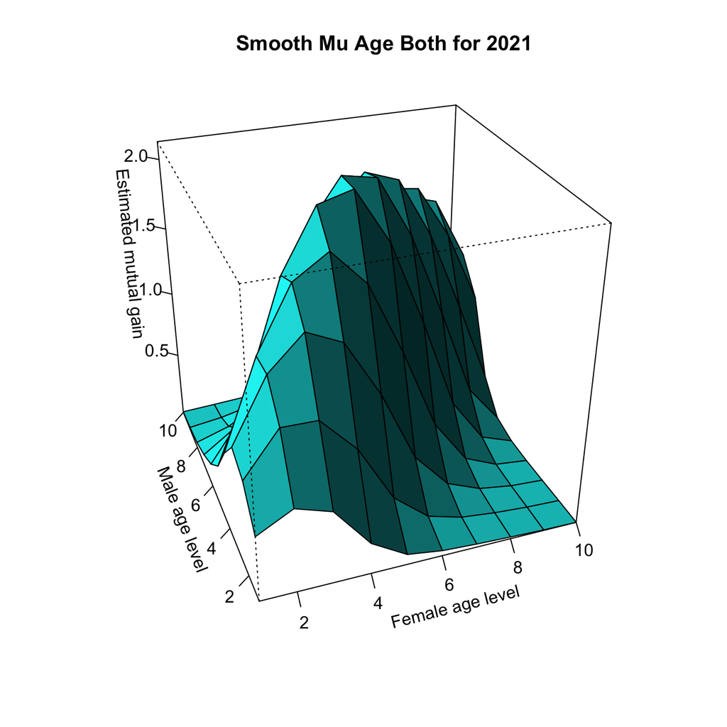

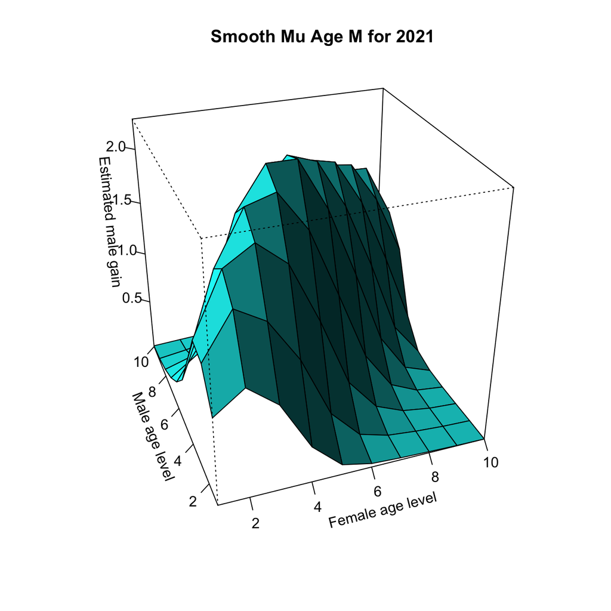

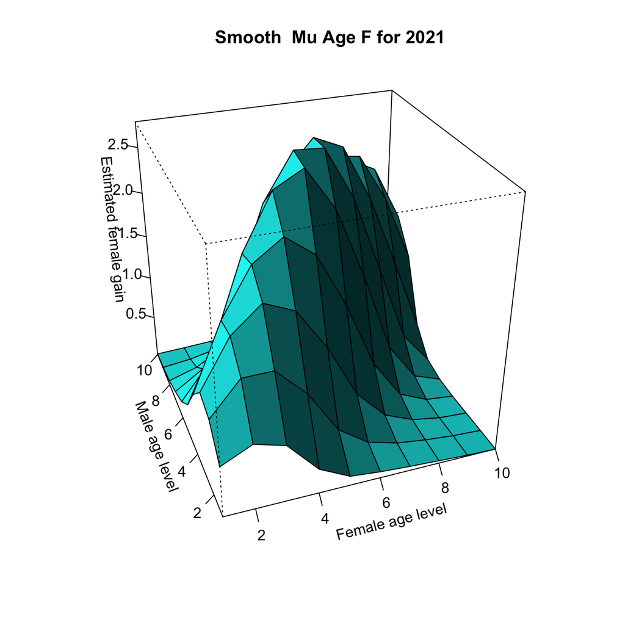

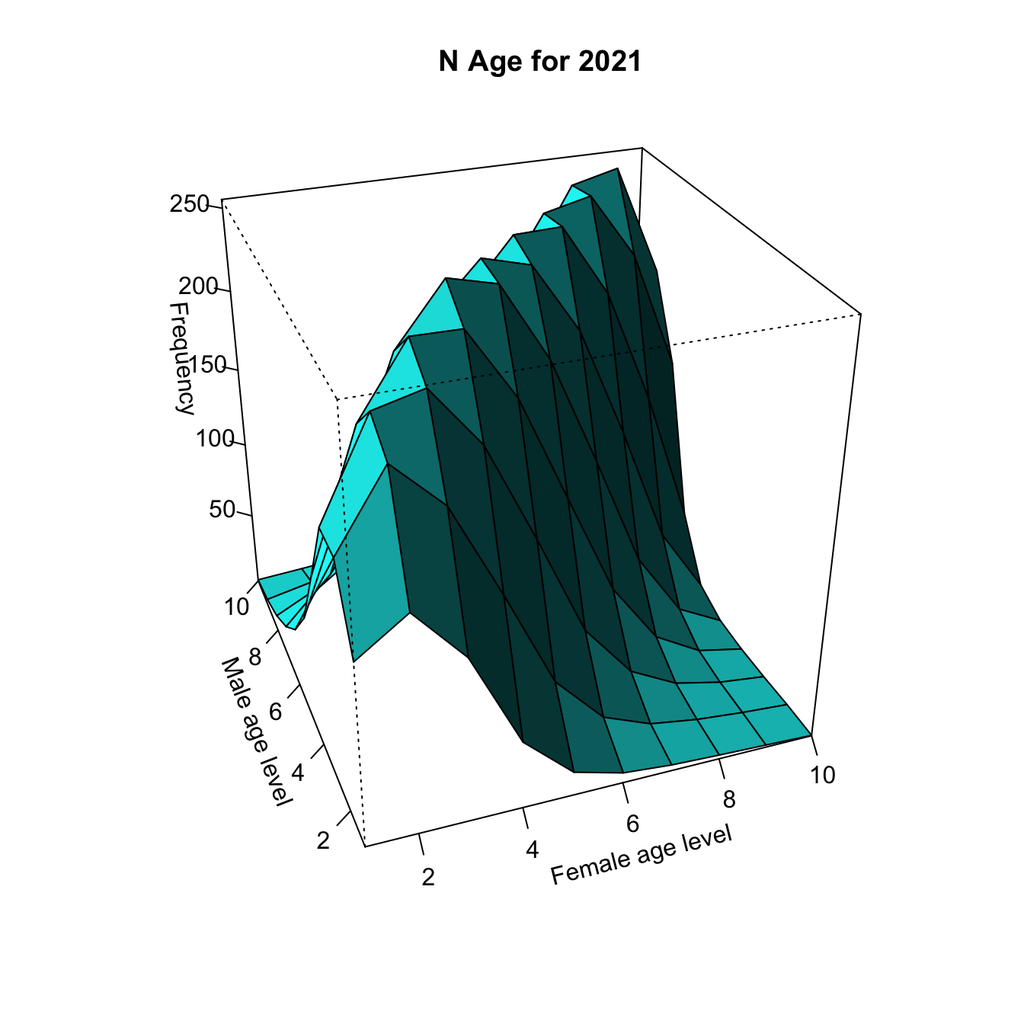

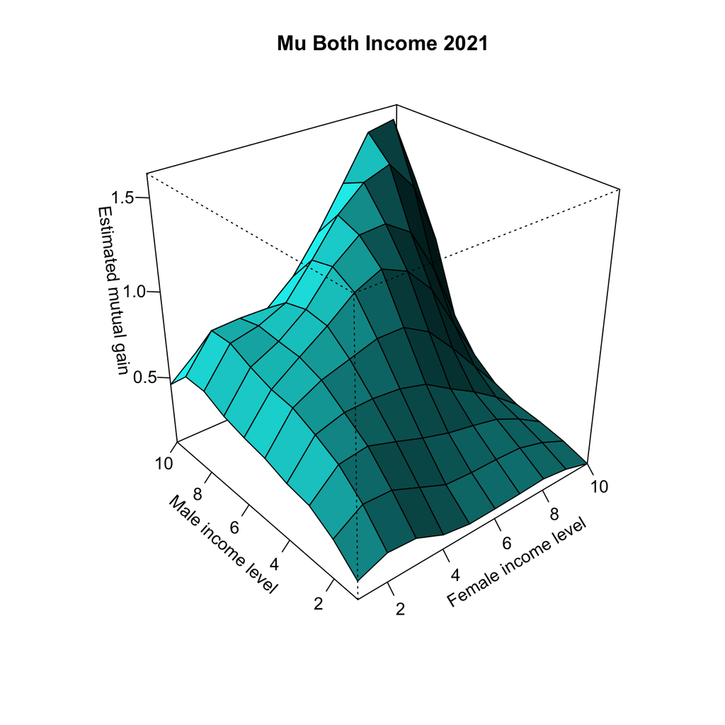

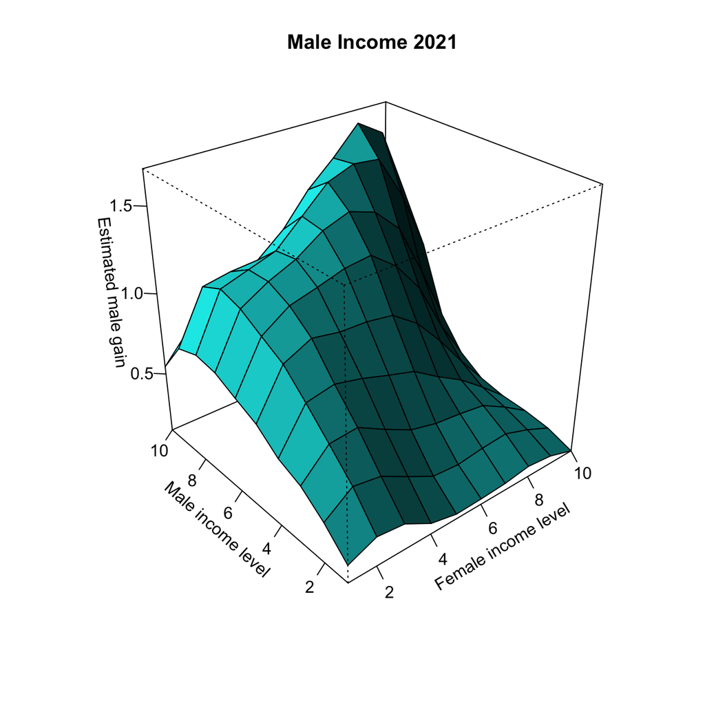

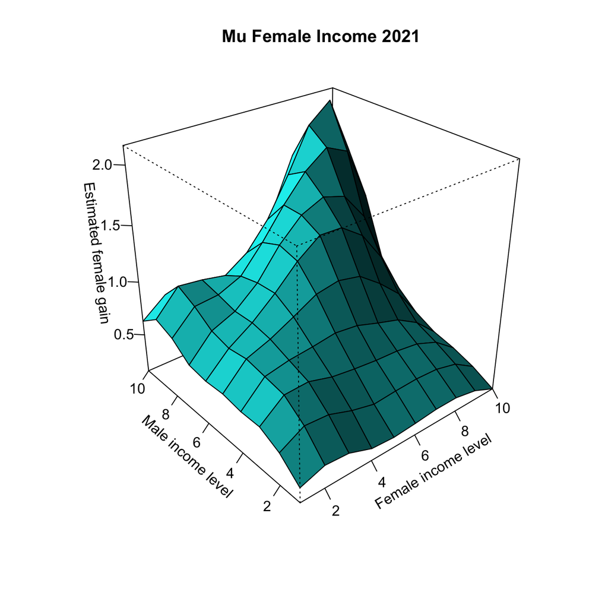

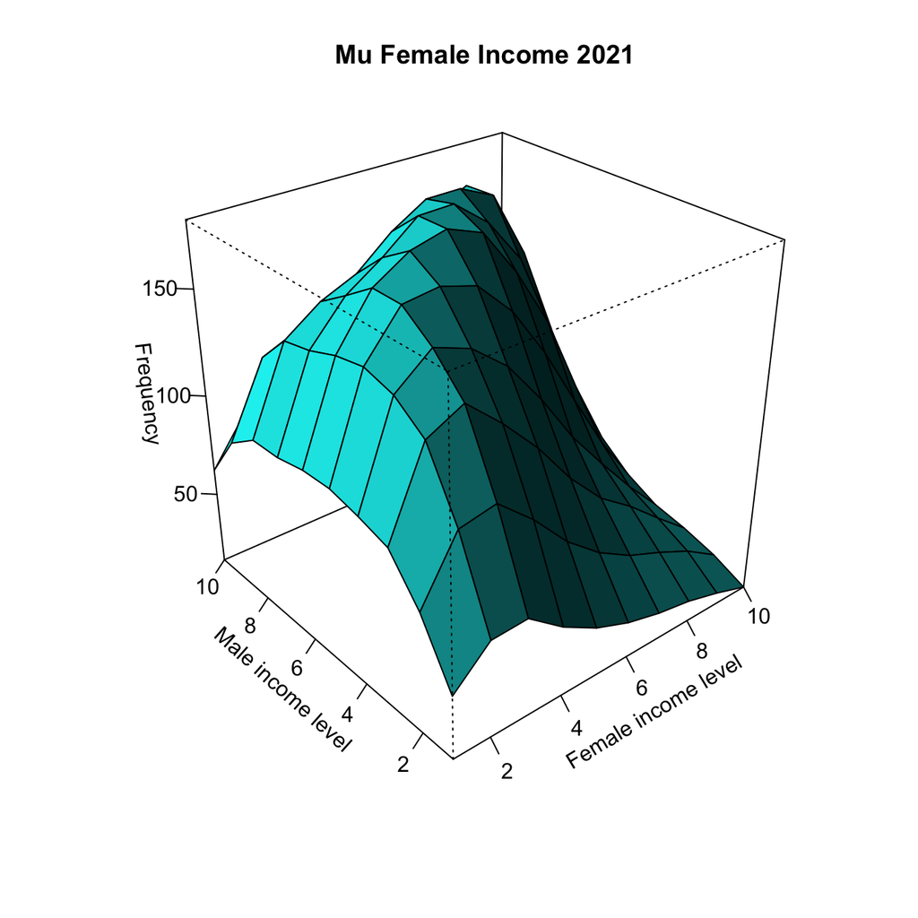

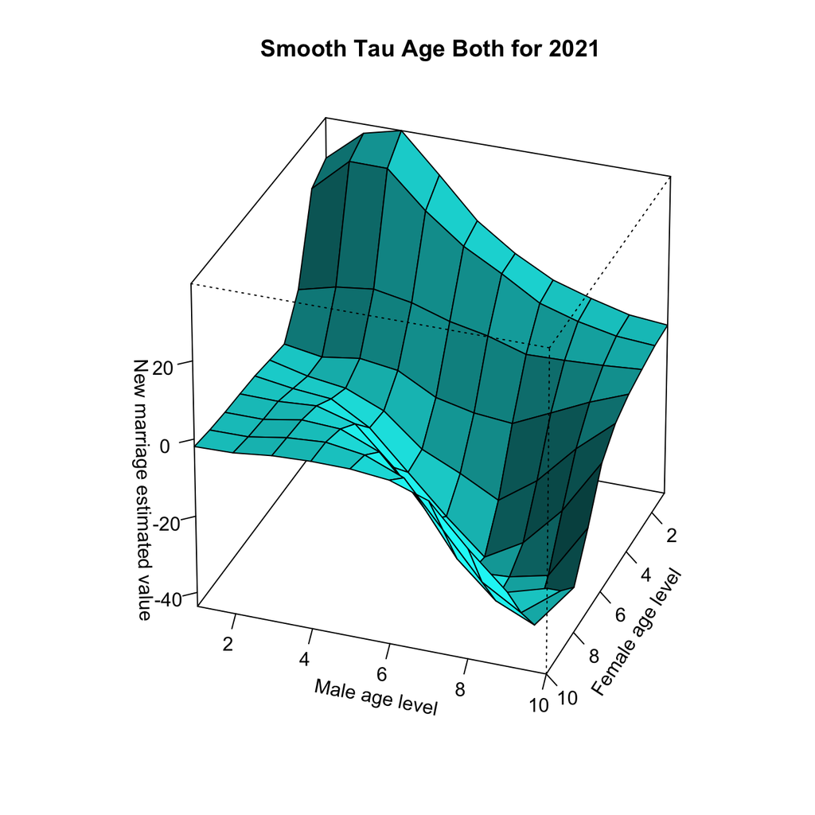

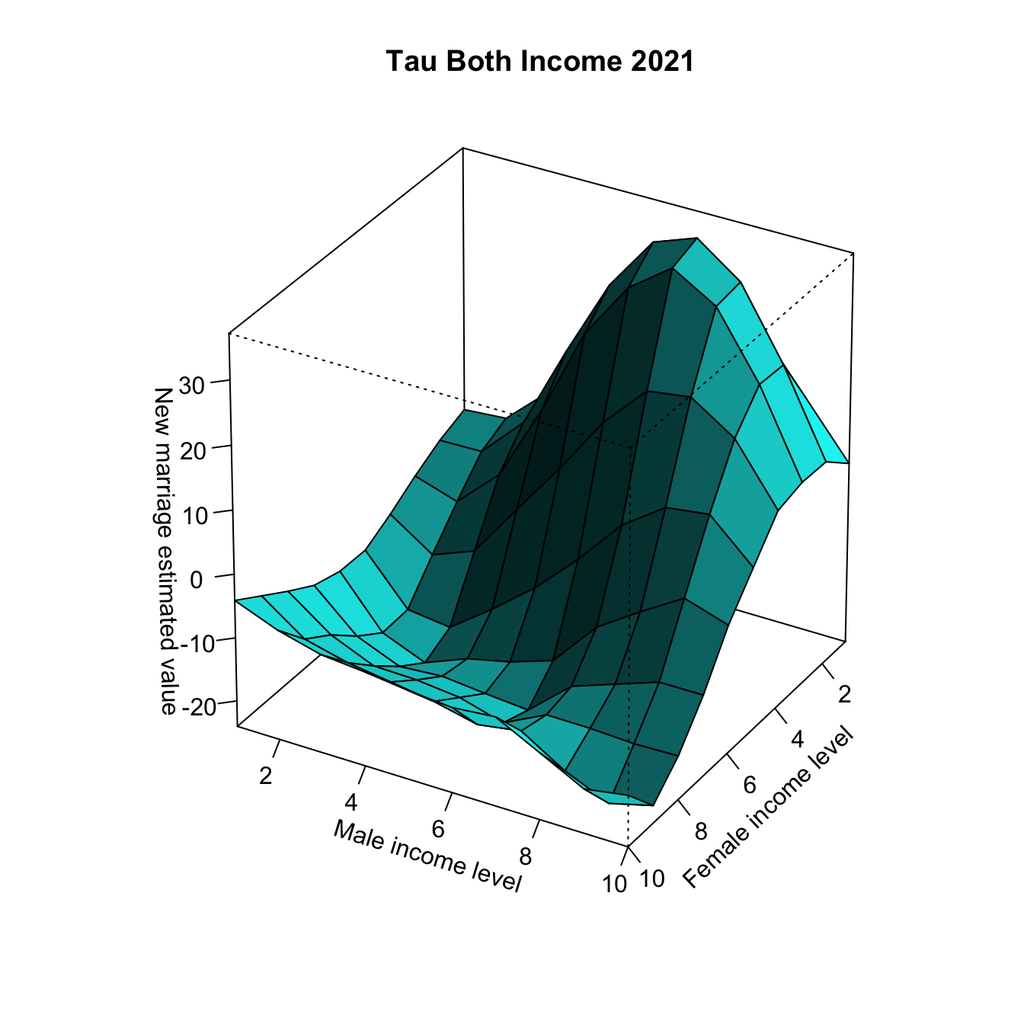

```r
draw(2021)
```